# News and Domain Sharing Analysis

Mapping Ideological Domains and the Factional Right-Wing Split

# Data

```r
# Information about politicians
nodes_breakdown <- read_csv(
  here("_processed_data", "nodes_breakdown.csv"))

# Domain data
account_by_media_domain_counts <- read_rds(
  here("_processed_data", "account_by_media_domain_counts.rds"))
```

## 1. Introduction and Methodological Rationale

This document establishes the pipeline for evaluating the media sharing behavior of the Brazilian parliament. Rather than relying on individual-level averages—which obscure highly concentrated alternative networks—this approach maps the ecosystem structurally.

We evaluate domains across two dimensions:

Ideological Center of Gravity: The weighted average ideology of the legislators sharing the domain.

Exclusivity (Echo-Chamber Index): The standard deviation of those ideological scores. Lower variance indicates a highly isolated, exclusive user base.

Subsequently, we isolate the political right to evaluate a specific structural fracture: the divergence between the populist “wolves” and the institutional “non-wolves right.” By calculating relative Attention Share budgets, we normalize for extreme group-size asymmetries and hyper-poster distortions, revealing a two-tiered media landscape.

## 2. Data Preparation and Hygiene

Before any statistical modeling, we must transform the wide sharing matrix into a long format. Crucially, we apply strict data hygiene filters. Social media APIs frequently log peer-to-peer retweets or shares of institutional pages as “domains.” Failing to remove these conflates intra-parliamentary homophily with actual journalistic media consumption.

We apply an automated filter to remove active parliamentarians and a hardcoded list to remove URL shorteners, party handles, and mismatched legacy URLs.

```r
# 1. Define the dynamic exclusion list from known authors (lowercased for strict matching)
politician_handles <- tolower(unique(nodes_breakdown$author))

# 2. Hardcoded exclusion vector for mismatched handles, URL shorteners, and institutional pages
manual_exclusions <- c(
  "lpbraganca", "pedrolupion", "sandersonfederal", "gurgelrj", "marcelvanhattem",
  "franciscojr", "deputadohugoleal", "evairdemelo", "charliesevangelista", "christinoaureo",
  "jaquelinecassol", "osiresdamaso", "renataabreuoficial", "domingossavio", "leandre",
  "joaoroma", "nereucrispim", "prb10", "agriculturarsgovbr", "portaltanosite",
  "blogdomarcosjunior", "gdia", "bitly", "republicanos10", "democratas", "camaralegbr"
)

# 3. Pivot and clean the base data
domain_long_clean <- account_by_media_domain_counts %>%
  as.data.frame() %>%
  rownames_to_column(var = "author") %>%
  pivot_longer(
    cols = -author,
    names_to = "domain",
    values_to = "share_count"
  ) %>%
  filter(share_count > 0) %>%
  # Automated filter
  filter(!tolower(domain) %in% politician_handles) %>%
  # Manual filter
  filter(!domain %in% manual_exclusions)
```

## 3. The 1D Baseline: Ideology, Frequency, and Dispersion

We first establish the ideological baseline for all shared domains across the entire parliament. We join the cleaned domain list with the nodes_breakdown metadata to calculate weighted means and standard deviations.

```r
domain_ideology_summary <- domain_long_clean %>%
  inner_join(
    nodes_breakdown %>% select(author, party, ideology_2021),
    by = "author"
  ) %>%
  group_by(domain) %>%
  summarise(
    total_shares = sum(share_count, na.rm = TRUE),

    # Weighted Mean
    weighted_mean_ideology = sum(share_count * ideology_2021, na.rm = TRUE) / total_shares,

    # Weighted Variance and Standard Deviation
    weighted_variance = sum(share_count * (ideology_2021 - weighted_mean_ideology)^2, na.rm = TRUE) / total_shares,
    weighted_sd_ideology = sqrt(weighted_variance),

    .groups = "drop"
  ) %>%
  filter(total_shares >= 10) %>%
  arrange(desc(total_shares))
```

We visualize this distribution, utilizing horizontal jitter to expose density and highlighting domains with low standard deviation (high exclusivity).

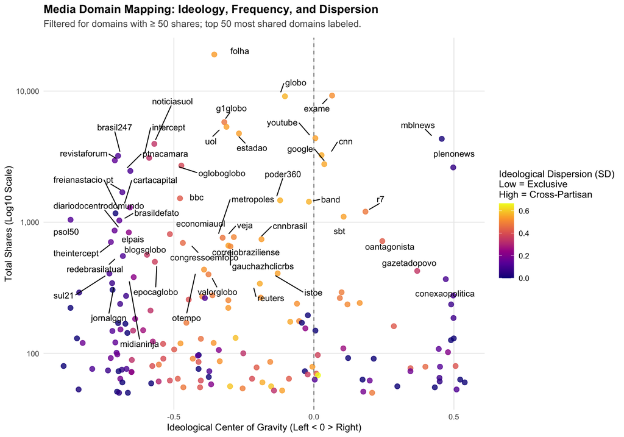

```r
# Filter out low-N noise to prevent false variance signals
filtered_summary <- domain_ideology_summary %>%
  filter(total_shares >= 50)

# Isolate the top domains for clean labeling
top_domains <- filtered_summary %>%
  slice_max(order_by = total_shares, n = 50)

ggplot(filtered_summary, aes(x = weighted_mean_ideology, y = total_shares)) +

  # Add slight horizontal jitter to expose density
  geom_jitter(
    aes(color = weighted_sd_ideology),
    width = 0.03, height = 0,
    alpha = 0.8, size = 2.5
  ) +
  scale_y_log10(labels = scales::comma) +
  geom_vline(xintercept = 0, linetype = "dashed", color = "gray50") +

  # Apply labels only to the isolated top dataframe
  geom_text_repel(
    data = top_domains,
    aes(label = domain),
    size = 3.5,
    box.padding = 0.8,
    point.padding = 0.3,
    max.overlaps = Inf,
    seed = 42
  ) +

  scale_color_viridis_c(
    option = "plasma",
    name = "Ideological Dispersion (SD)\nLow = Exclusive\nHigh = Cross-Partisan"
  ) +

  labs(
    title = "Media Domain Mapping: Ideology, Frequency, and Dispersion",
    subtitle = "Filtered for domains with ≥ 50 shares; top 50 most shared domains labeled.",
    x = "Ideological Center of Gravity (Left < 0 > Right)",
    y = "Total Shares (Log10 Scale)"
  ) +
  theme_minimal() +
  theme(
    plot.title = element_text(face = "bold"),
    plot.subtitle = element_text(color = "gray30", margin = margin(b = 10)),
    legend.position = "right",
    panel.grid.minor = element_blank()
  )
```

## 4. The Right-Wing Split: Attention Share & Media Diet Space

To test whether the populist “wolves” utilize a distinct alternative media infrastructure compared to the “non-wolves right,” we subset the data.Because the non-wolves right is a much larger group, raw share counts and user prevalence metrics are statistically compromised by the base-rate fallacy. We resolve this by computing the Relative Attention Share. We treat each faction’s total output as a “Media Diet Budget” ($B_f$) and calculate the percentage allocated to domain $d$:
$$\text{Attention Share}_{d, f} =
\frac{\text{Shares of } d \text{ by Faction } f}{B_f} \times 100$$

```r
# Isolate the right wing
right_nodes <- nodes_breakdown %>% filter(ideology_2021 > 0)
right_shares_clean <- domain_long_clean %>%
  inner_join(right_nodes %>% select(author, is_wolf), by = "author")

# Calculate Total Media Output (The Denominators)
group_budgets <- right_shares_clean %>%
  group_by(is_wolf) %>%
  summarise(total_faction_shares = sum(share_count), .groups = "drop")

total_w_shares <- group_budgets %>% filter(is_wolf == 1) %>% pull(total_faction_shares)
total_nw_shares <- group_budgets %>% filter(is_wolf == 0) %>% pull(total_faction_shares)

# Compute Attention Share per Domain
media_diet_base <- right_shares_clean %>%
  group_by(is_wolf, domain) %>%
  summarise(domain_faction_shares = sum(share_count), .groups = "drop") %>%
  pivot_wider(names_from = is_wolf, values_from = domain_faction_shares, values_fill = 0, names_prefix = "shares_") %>%
  rename(nw_shares = shares_0, w_shares = shares_1) %>%
  mutate(
    pct_of_wolf_diet = (w_shares / total_w_shares) * 100,
    pct_of_nonwolf_diet = (nw_shares / total_nw_shares) * 100,
    total_volume = w_shares + nw_shares,
    diet_ratio = (pct_of_wolf_diet + 0.001) / (pct_of_nonwolf_diet + 0.001)
  ) %>%
  filter(total_volume >= 20)

# Inject Domain-Level Ideology and Exclusivity Metadata
media_diet_enriched <- media_diet_base %>%
  left_join(
    domain_ideology_summary %>%
      select(domain, weighted_mean_ideology, weighted_sd_ideology),
    by = "domain"
  )
```

Final Visualization: The Two-Tiered Media Landscape We plot the media diet space, rendering the domains as points colored by their underlying ideological score and adjusted for transparency based on exclusivity.

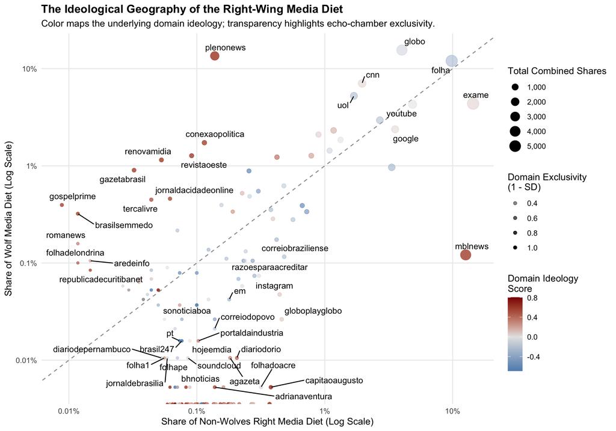

```r
ggplot(media_diet_enriched, aes(x = pct_of_nonwolf_diet, y = pct_of_wolf_diet)) +

  # 45-degree identity line (Equal structural attention)
  geom_abline(intercept = 0, slope = 1, linetype = "dashed", color = "gray60") +

  geom_point(aes(color = weighted_mean_ideology, size = total_volume, alpha = 1 - weighted_sd_ideology)) +

  scale_x_log10(labels = function(x) paste0(x, "%")) +
  scale_y_log10(labels = function(x) paste0(x, "%")) +

  scale_color_gradient2(
    low = "steelblue",
    mid = "gray90",
    high = "darkred",
    midpoint = 0,
    name = "Domain Ideology\nScore"
  ) +

  scale_alpha_continuous(name = "Domain Exclusivity\n(1 - SD)", range = c(0.4, 1)) +
  scale_size_continuous(name = "Total Combined Shares", labels = scales::comma) +

  # Strict label filtering to prevent clutter in the low-volume tail
  geom_text_repel(
    data = media_diet_enriched %>% filter(diet_ratio > 3.5 | diet_ratio < 0.25 | total_volume > 1500),
    aes(label = domain),
    size = 3.5,
    box.padding = 0.4,
    max.overlaps = 25
  ) +

  labs(
    title = "The Ideological Geography of the Right-Wing Media Diet",
    subtitle = "Color maps the underlying domain ideology; transparency highlights echo-chamber exclusivity.",
    x = "Share of Non-Wolves Right Media Diet (Log Scale)",
    y = "Share of Wolf Media Diet (Log Scale)"
  ) +
  theme_minimal() +
  theme(
    plot.title = element_text(face = "bold"),
    panel.grid.minor = element_blank(),
    legend.position = "right"
  )
```